**Задача:** построить скоринг модель для вторичных клиентов банка, которая бы предсказывала вероятность дефолта клиента.

# Основные этапы решения задачи:

- Постановка задачи
- Предобработка данных
- Формирование признаков
- Выбор метрики качества
- Построение модели
- Оценивание качества модели

### Предобработка данных

[Текст взят отсюда](https://github.com/esokolov/ml-course-hse/blob/master/2016-fall/lecture-notes/lecture01-intro.pdf)

- Некоторые модели хорошо работают только при выполнении определенных требований. Так, для линейных моделей крайне важно, чтобы признаки были нормированными, то есть измерялись в одной шкале. Примером способа норми- ровки данных является вычитание среднего и деление на дисперсию каждого столбца в матрице «объекты-признаки».
- Бывает, что в выборку попадают выбросы — объекты, которые не являются корректными примерами из-за неправильно посчитанных признаков, ошибки сбора данных или чего-то еще. Их наличие может сильно испортить модель.
- Некоторые признаки могут оказаться шумовыми, то есть не имеющими никакого отношения к целевой переменной и к решаемой задаче. Примером, скорее всего, может служить признак «фаза луны в день первого экзамена» в задаче предсказания успешности прохождения сессии студентом.

### Формирование признаков

[Текст частично взят отсюда](https://habr.com/ru/company/ods/blog/325422/#vremennye-ryady-veb-i-prochee)

**Три основных шага в этом пункте:**

- **Извлечение признаков (Feature Extraction)**

> В задаче 3-го проекта можно было добавить целый ряд дополнительных признаков: всевозможные рейтинги, страны, населенность и тд. Из существующих признаков можно было извлечь названия кухонь, поработать с отзывами и тд.

> Извлечение и формирование признаков - настоящее искусство :) Иногда для формирования новых признаков я лезу в google scholar, вбиваю там примерное описание своей задачи, нахожу разные статьи и подсматриваю, какие фичи использовались в этих статьях.

> Есть целые библиотеки, которые помогают в формировании фичей. Например, я работаю с сигналами и для этого есть библиотека `tsfresh`, помогающая сформировать все математические признаки сигнала. Когда работала со звуком (задача классификации болезней легких по записанному звуку дыхания), использовала библиотеки `raphaelvallat` и `librosa`.
- **Преобразования признаков (Feature transformations)**

> Для каждого семейства моделей изучаем, как преобразовывать признаки и что для модели ок/не ок.
- **Выбор признаков (Feature selection)**

> Самый простой способ - построить корреляционную матрицу и удалить параметры, коррелирующие между собой.

> Статистические инструменты

> После обучения делать feature importance

### Выбор метрики качества

Ниже в теоретической части + прошлые итоговые разборы (внимательно изучаем метрики!).

### Построение модели

### Оценивание качества модели

Необходимо отделить тестовую от трейновой части, итоговая проверка происходит на тесте.

Проблема: результат сильно зависит от того, как именно вы отделили тест от трейна.

Решение: Кросс-валидация.

**ВОПРОСЫ**

> Добрый день! Хотелось бы узнать как анализировать обученную модель, как понять какие признаки вносят больший/меньший вклад , и вообще про реакцию модели на признак.то есть влияет ли как то нлрмальзованность признака или ее отсутствие на результат модели. Естественно можно переобучить и посмотреть , но так это превратится в перебор

> Наверно на разборе хотелось бы больше теории, всё таки. Касаемо параметров и настройки модели обучения. Временами нет ясности и получается копрование, по большей части, без понимания. (edited)

> в частности, если честно, порой есть беда с пониманием последовательности действий. Своего рода алгоритма. С подготовкой данных всё ясно, а вот дальше, когда идет речь об оценке качества модели, её параметры и тд

# Практическая часть

## 1. Импорт библиотек

```python
import numpy as np # linear algebra
import pandas as pd # data processing, CSV file I/O (e.g. pd.read_csv)

import matplotlib.pyplot as plt
import seaborn as sns
from sklearn import preprocessing
%matplotlib inline

# Загружаем специальный удобный инструмент для разделения датасета:
from sklearn.model_selection import train_test_split
from sklearn.metrics import auc, roc_auc_score, roc_curve, accuracy_score, balanced_accuracy_score, precision_score, recall_score, f1_score
from sklearn.model_selection import cross_val_score
from sklearn.linear_model import LogisticRegression
from sklearn.neighbors import KNeighborsClassifier
from sklearn.naive_bayes import GaussianNB
from sklearn.ensemble import RandomForestClassifier
from sklearn.ensemble import GradientBoostingClassifier

# всегда фиксируйте RANDOM_SEED, чтобы ваши эксперименты были воспроизводимы!
RANDOM_SEED = 42
```

## 2. Предобработка данных

1. Смотрим датасеты: корректно ли все отображается
2. Соединяем датасеты
3. Заполняем пропуски
4. Смотрим выбросы
5. Визуализируем и изучаем

```python
df_train = pd.read_csv('sf-dst-scoring/train.csv')
df_test = pd.read_csv('sf-dst-scoring/test.csv')
pd.set_option('display.max_columns', None)
print('Размерность тренировочного датасета: ', df_train.shape)
display(df_train.head())
print('Размерность тестового датасета: ', df_test.shape)
display(df_test.head())

'''
ВНИМАТЕЛЬНО: Перед обработкой всегда объединяем тестовую и трейновую часть
для корректной обработки датасета.

Внимательно также смотрим, чтобы трейновая и тестовая часть не мешались между собой.

Какие ошибки могут быть? Например, вы обрабатываете данные с датчиков или аудио.
Вы берете запись (данные с датчика или аудио) и разбиваете все на 10-секундные отрезки (пример).

Обрабатываете их, формируете фичи и затем формируете тестовую и трейновую часть.

Дело в том, что у вас будет некорректные результаты МЛ обучения, так как разные куски
одной(!) записи могут быть в трейне и тесте.
'''


# Для корректной обработки признаков объединяем трейн и тест в один датасет
df_train['Train'] = 1 # помечаем где у нас трейн
df_test['Train'] = 0 # помечаем где у нас тест

df = df_train.append(df_test, sort=False).reset_index(drop=True) # объединяем

print(' ')
print('Смотрим на общую информацию о датасете:')
print(' ')

print(df.info())
```

```
Размерность тренировочного датасета:  (73799, 19)
```

|  | client_id | app_date | education | sex | age | car | car_type | decline_app_cnt | good_work | score_bki | bki_request_cnt | region_rating | home_address | work_address | income | sna | first_time | foreign_passport | default |
| --- | --- | --- | --- | --- | --- | --- | --- | --- | --- | --- | --- | --- | --- | --- | --- | --- | --- | --- | --- |
| 0 | 25905 | 01FEB2014 | SCH | M | 62 | Y | Y | 0 | 0 | -2.008753 | 1 | 50 | 1 | 2 | 18000 | 4 | 1 | N | 0 |
| 1 | 63161 | 12MAR2014 | SCH | F | 59 | N | N | 0 | 0 | -1.532276 | 3 | 50 | 2 | 3 | 19000 | 4 | 1 | N | 0 |
| 2 | 25887 | 01FEB2014 | SCH | M | 25 | Y | N | 2 | 0 | -1.408142 | 1 | 80 | 1 | 2 | 30000 | 1 | 4 | Y | 0 |
| 3 | 16222 | 23JAN2014 | SCH | F | 53 | N | N | 0 | 0 | -2.057471 | 2 | 50 | 2 | 3 | 10000 | 1 | 3 | N | 0 |
| 4 | 101655 | 18APR2014 | GRD | M | 48 | N | N | 0 | 1 | -1.244723 | 1 | 60 | 2 | 3 | 30000 | 1 | 4 | Y | 0 |

```
Размерность тестового датасета:  (36349, 18)
```

|  | client_id | app_date | education | sex | age | car | car_type | decline_app_cnt | good_work | score_bki | bki_request_cnt | region_rating | home_address | work_address | income | sna | first_time | foreign_passport |
| --- | --- | --- | --- | --- | --- | --- | --- | --- | --- | --- | --- | --- | --- | --- | --- | --- | --- | --- |
| 0 | 74835 | 22MAR2014 | GRD | M | 29 | Y | Y | 0 | 0 | -2.271884 | 3 | 50 | 1 | 2 | 50000 | 1 | 4 | N |
| 1 | 17527 | 24JAN2014 | SCH | F | 39 | N | N | 5 | 0 | -1.504999 | 2 | 50 | 1 | 2 | 5000 | 4 | 3 | N |
| 2 | 75683 | 23MAR2014 | UGR | M | 50 | Y | Y | 0 | 0 | -1.691339 | 1 | 50 | 1 | 2 | 30000 | 1 | 3 | Y |
| 3 | 26883 | 03FEB2014 | SCH | M | 56 | N | N | 0 | 0 | -2.374182 | 1 | 40 | 1 | 2 | 17000 | 1 | 3 | N |
| 4 | 28862 | 04FEB2014 | GRD | F | 38 | N | N | 0 | 0 | -2.487502 | 0 | 80 | 2 | 3 | 120000 | 1 | 3 | N |

```
Смотрим на общую информацию о датасете:

<class 'pandas.core.frame.DataFrame'>
RangeIndex: 110148 entries, 0 to 110147
Data columns (total 20 columns):
 #   Column            Non-Null Count   Dtype
---  ------            --------------   -----
 0   client_id         110148 non-null  int64
 1   app_date          110148 non-null  object
 2   education         109670 non-null  object
 3   sex               110148 non-null  object
 4   age               110148 non-null  int64
 5   car               110148 non-null  object
 6   car_type          110148 non-null  object
 7   decline_app_cnt   110148 non-null  int64
 8   good_work         110148 non-null  int64
 9   score_bki         110148 non-null  float64
 10  bki_request_cnt   110148 non-null  int64
 11  region_rating     110148 non-null  int64
 12  home_address      110148 non-null  int64
 13  work_address      110148 non-null  int64
 14  income            110148 non-null  int64
 15  sna               110148 non-null  int64
 16  first_time        110148 non-null  int64
 17  foreign_passport  110148 non-null  object
 18  default           73799 non-null   float64
 19  Train             110148 non-null  int64
dtypes: float64(2), int64(12), object(6)
memory usage: 16.8+ MB
None
```

Описания полей датасета

- **client_id** - идентификатор клиента
- **education** - уровень образования
- **sex** - пол заемщика
- **age** - возраст заемщика
- **car** - флаг наличия автомобиля
- **car_type** - флаг автомобиля иномарки
- **decline_app_cnt** - количество отказанных прошлых заявок
- **good_work** - флаг наличия “хорошей” работы
- **bki_request_cnt** - количество запросов в БКИ
- **home_address** - категоризатор домашнего адреса
- **work_address** - категоризатор рабочего адреса
- **income** - доход заемщика
- **foreign_passport** - наличие загранпаспорта
- **sna** - связь заемщика с клиентами банка
- **first_time** - давность наличия информации о заемщике
- **score_bki** - скоринговый балл по данным из БКИ
- **region_rating** - рейтинг региона
- **app_date** - дата подачи заявки
- **default** - флаг дефолта по кредиту

### 2.1 EDA

#### client_id

```python
print(df['client_id'].describe())
print('Количество уникальных зачений:', len(df['client_id']))
```

```
count    110148.000000
mean      55074.500000
std       31797.133063
min           1.000000
25%       27537.750000
50%       55074.500000
75%       82611.250000
max      110148.000000
Name: client_id, dtype: float64
Количество уникальных зачений: 110148
```

#### education

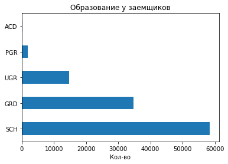

```python
df['education'].value_counts().plot.barh()
plt.title('Образование у заемщиков')
plt.xlabel('Кол-во')
plt.show()

'''
У нас пропуски в разделе "образования",
путем EDA мы заполняем пропуски самым популярным значением
'''

df['education'] = df['education'].fillna('SCH')
```

#### region_rating

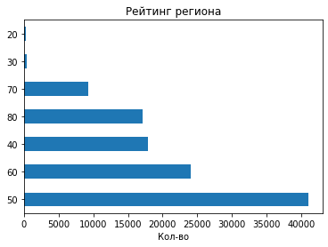

```python
df['region_rating'].value_counts().plot.barh()
plt.title('Рейтинг региона')
plt.xlabel('Кол-во')
plt.show()
```

Для красоты визуализации: https://seaborn.pydata.org/examples/index.html

## 3. Формирование признаков

1. Все строковые переменные переводим в числовые
2. Не допускаем никаких(!) других форматов, кроме числовых (аккуратнее с Timestep'ами)
3. Формируем новые фичи

#### app_date

```python
# Преобразуем признак app_date в нужный формат
df.app_date = pd.to_datetime(df.app_date, format='%d%b%Y')
print(df.app_date.sample(1))

# Выясняем начало и конец периода нашего датасета
start = df.app_date.min()
end = df.app_date.max()
print('Начало:', start, 'Конец:', end)

# Вводим новый признак: разница от начала до дня заявки
df['days'] = (df.app_date - start).dt.days.astype('int')

df.drop(['app_date'], axis=1, inplace=True)
display(df.head())
```

```
54873   2014-04-10
Name: app_date, dtype: datetime64[ns]
Начало: 2014-01-01 00:00:00 Конец: 2014-04-30 00:00:00
```

|  | client_id | education | sex | age | car | car_type | decline_app_cnt | good_work | score_bki | bki_request_cnt | region_rating | home_address | work_address | income | sna | first_time | foreign_passport | default | Train | days |
| --- | --- | --- | --- | --- | --- | --- | --- | --- | --- | --- | --- | --- | --- | --- | --- | --- | --- | --- | --- | --- |
| 0 | 25905 | SCH | M | 62 | Y | Y | 0 | 0 | -2.008753 | 1 | 50 | 1 | 2 | 18000 | 4 | 1 | N | 0.0 | 1 | 31 |
| 1 | 63161 | SCH | F | 59 | N | N | 0 | 0 | -1.532276 | 3 | 50 | 2 | 3 | 19000 | 4 | 1 | N | 0.0 | 1 | 70 |
| 2 | 25887 | SCH | M | 25 | Y | N | 2 | 0 | -1.408142 | 1 | 80 | 1 | 2 | 30000 | 1 | 4 | Y | 0.0 | 1 | 31 |
| 3 | 16222 | SCH | F | 53 | N | N | 0 | 0 | -2.057471 | 2 | 50 | 2 | 3 | 10000 | 1 | 3 | N | 0.0 | 1 | 22 |
| 4 | 101655 | GRD | M | 48 | N | N | 0 | 1 | -1.244723 | 1 | 60 | 2 | 3 | 30000 | 1 | 4 | Y | 0.0 | 1 | 107 |

#### education

```python
education = df['education'].to_frame()
education_le = education.apply(preprocessing.LabelEncoder().fit_transform)
df['education'] = education_le

display(df.head())
```

|  | client_id | education | sex | age | car | car_type | decline_app_cnt | good_work | score_bki | bki_request_cnt | region_rating | home_address | work_address | income | sna | first_time | foreign_passport | default | Train | days |
| --- | --- | --- | --- | --- | --- | --- | --- | --- | --- | --- | --- | --- | --- | --- | --- | --- | --- | --- | --- | --- |
| 0 | 25905 | 3 | M | 62 | Y | Y | 0 | 0 | -2.008753 | 1 | 50 | 1 | 2 | 18000 | 4 | 1 | N | 0.0 | 1 | 31 |
| 1 | 63161 | 3 | F | 59 | N | N | 0 | 0 | -1.532276 | 3 | 50 | 2 | 3 | 19000 | 4 | 1 | N | 0.0 | 1 | 70 |
| 2 | 25887 | 3 | M | 25 | Y | N | 2 | 0 | -1.408142 | 1 | 80 | 1 | 2 | 30000 | 1 | 4 | Y | 0.0 | 1 | 31 |
| 3 | 16222 | 3 | F | 53 | N | N | 0 | 0 | -2.057471 | 2 | 50 | 2 | 3 | 10000 | 1 | 3 | N | 0.0 | 1 | 22 |
| 4 | 101655 | 1 | M | 48 | N | N | 0 | 1 | -1.244723 | 1 | 60 | 2 | 3 | 30000 | 1 | 4 | Y | 0.0 | 1 | 107 |

#### sex

```python
sex = df['sex'].to_frame()
sex_le = sex.apply(preprocessing.LabelEncoder().fit_transform)
df['sex'] = sex_le

display(df.head())
```

|  | client_id | education | sex | age | car | car_type | decline_app_cnt | good_work | score_bki | bki_request_cnt | region_rating | home_address | work_address | income | sna | first_time | foreign_passport | default | Train | days |
| --- | --- | --- | --- | --- | --- | --- | --- | --- | --- | --- | --- | --- | --- | --- | --- | --- | --- | --- | --- | --- |
| 0 | 25905 | 3 | 1 | 62 | Y | Y | 0 | 0 | -2.008753 | 1 | 50 | 1 | 2 | 18000 | 4 | 1 | N | 0.0 | 1 | 31 |
| 1 | 63161 | 3 | 0 | 59 | N | N | 0 | 0 | -1.532276 | 3 | 50 | 2 | 3 | 19000 | 4 | 1 | N | 0.0 | 1 | 70 |
| 2 | 25887 | 3 | 1 | 25 | Y | N | 2 | 0 | -1.408142 | 1 | 80 | 1 | 2 | 30000 | 1 | 4 | Y | 0.0 | 1 | 31 |
| 3 | 16222 | 3 | 0 | 53 | N | N | 0 | 0 | -2.057471 | 2 | 50 | 2 | 3 | 10000 | 1 | 3 | N | 0.0 | 1 | 22 |
| 4 | 101655 | 1 | 1 | 48 | N | N | 0 | 1 | -1.244723 | 1 | 60 | 2 | 3 | 30000 | 1 | 4 | Y | 0.0 | 1 | 107 |

#### car

```python
car = df['car'].to_frame()
car_le = car.apply(preprocessing.LabelEncoder().fit_transform)
df['car'] = car_le

display(df.head())
```

|  | client_id | education | sex | age | car | car_type | decline_app_cnt | good_work | score_bki | bki_request_cnt | region_rating | home_address | work_address | income | sna | first_time | foreign_passport | default | Train | days |
| --- | --- | --- | --- | --- | --- | --- | --- | --- | --- | --- | --- | --- | --- | --- | --- | --- | --- | --- | --- | --- |
| 0 | 25905 | 3 | 1 | 62 | 1 | Y | 0 | 0 | -2.008753 | 1 | 50 | 1 | 2 | 18000 | 4 | 1 | N | 0.0 | 1 | 31 |
| 1 | 63161 | 3 | 0 | 59 | 0 | N | 0 | 0 | -1.532276 | 3 | 50 | 2 | 3 | 19000 | 4 | 1 | N | 0.0 | 1 | 70 |
| 2 | 25887 | 3 | 1 | 25 | 1 | N | 2 | 0 | -1.408142 | 1 | 80 | 1 | 2 | 30000 | 1 | 4 | Y | 0.0 | 1 | 31 |
| 3 | 16222 | 3 | 0 | 53 | 0 | N | 0 | 0 | -2.057471 | 2 | 50 | 2 | 3 | 10000 | 1 | 3 | N | 0.0 | 1 | 22 |
| 4 | 101655 | 1 | 1 | 48 | 0 | N | 0 | 1 | -1.244723 | 1 | 60 | 2 | 3 | 30000 | 1 | 4 | Y | 0.0 | 1 | 107 |

#### car_type

```python
car_type = df['car_type'].to_frame()
car_type_le = car_type.apply(preprocessing.LabelEncoder().fit_transform)
df['car_type'] = car_type_le

display(df.head())
```

|  | client_id | education | sex | age | car | car_type | decline_app_cnt | good_work | score_bki | bki_request_cnt | region_rating | home_address | work_address | income | sna | first_time | foreign_passport | default | Train | days |
| --- | --- | --- | --- | --- | --- | --- | --- | --- | --- | --- | --- | --- | --- | --- | --- | --- | --- | --- | --- | --- |
| 0 | 25905 | 3 | 1 | 62 | 1 | 1 | 0 | 0 | -2.008753 | 1 | 50 | 1 | 2 | 18000 | 4 | 1 | N | 0.0 | 1 | 31 |
| 1 | 63161 | 3 | 0 | 59 | 0 | 0 | 0 | 0 | -1.532276 | 3 | 50 | 2 | 3 | 19000 | 4 | 1 | N | 0.0 | 1 | 70 |
| 2 | 25887 | 3 | 1 | 25 | 1 | 0 | 2 | 0 | -1.408142 | 1 | 80 | 1 | 2 | 30000 | 1 | 4 | Y | 0.0 | 1 | 31 |
| 3 | 16222 | 3 | 0 | 53 | 0 | 0 | 0 | 0 | -2.057471 | 2 | 50 | 2 | 3 | 10000 | 1 | 3 | N | 0.0 | 1 | 22 |
| 4 | 101655 | 1 | 1 | 48 | 0 | 0 | 0 | 1 | -1.244723 | 1 | 60 | 2 | 3 | 30000 | 1 | 4 | Y | 0.0 | 1 | 107 |

#### foreign_passport

```python
foreign_passport = df['foreign_passport'].to_frame()
foreign_passport_le = foreign_passport.apply(preprocessing.LabelEncoder().fit_transform)
df['foreign_passport'] = foreign_passport_le

display(df.head())
```

|  | client_id | education | sex | age | car | car_type | decline_app_cnt | good_work | score_bki | bki_request_cnt | region_rating | home_address | work_address | income | sna | first_time | foreign_passport | default | Train | days |
| --- | --- | --- | --- | --- | --- | --- | --- | --- | --- | --- | --- | --- | --- | --- | --- | --- | --- | --- | --- | --- |
| 0 | 25905 | 3 | 1 | 62 | 1 | 1 | 0 | 0 | -2.008753 | 1 | 50 | 1 | 2 | 18000 | 4 | 1 | 0 | 0.0 | 1 | 31 |
| 1 | 63161 | 3 | 0 | 59 | 0 | 0 | 0 | 0 | -1.532276 | 3 | 50 | 2 | 3 | 19000 | 4 | 1 | 0 | 0.0 | 1 | 70 |
| 2 | 25887 | 3 | 1 | 25 | 1 | 0 | 2 | 0 | -1.408142 | 1 | 80 | 1 | 2 | 30000 | 1 | 4 | 1 | 0.0 | 1 | 31 |
| 3 | 16222 | 3 | 0 | 53 | 0 | 0 | 0 | 0 | -2.057471 | 2 | 50 | 2 | 3 | 10000 | 1 | 3 | 0 | 0.0 | 1 | 22 |
| 4 | 101655 | 1 | 1 | 48 | 0 | 0 | 0 | 1 | -1.244723 | 1 | 60 | 2 | 3 | 30000 | 1 | 4 | 1 | 0.0 | 1 | 107 |

```python
df.info()
```

```
<class 'pandas.core.frame.DataFrame'>
RangeIndex: 110148 entries, 0 to 110147
Data columns (total 20 columns):
 #   Column            Non-Null Count   Dtype
---  ------            --------------   -----
 0   client_id         110148 non-null  int64
 1   education         110148 non-null  int64
 2   sex               110148 non-null  int64
 3   age               110148 non-null  int64
 4   car               110148 non-null  int64
 5   car_type          110148 non-null  int64
 6   decline_app_cnt   110148 non-null  int64
 7   good_work         110148 non-null  int64
 8   score_bki         110148 non-null  float64
 9   bki_request_cnt   110148 non-null  int64
 10  region_rating     110148 non-null  int64
 11  home_address      110148 non-null  int64
 12  work_address      110148 non-null  int64
 13  income            110148 non-null  int64
 14  sna               110148 non-null  int64
 15  first_time        110148 non-null  int64
 16  foreign_passport  110148 non-null  int64
 17  default           73799 non-null   float64
 18  Train             110148 non-null  int64
 19  days              110148 non-null  int64
dtypes: float64(2), int64(18)
memory usage: 16.8 MB
```

### 3.1 Выбор признаков

Method of correlation:

- **pearson : standard correlation coefficient**

> метод параметрической статистики, позволяющий определить наличие или отсутствие линейной связи между двумя количественными показателями, а также оценить ее тесноту и статистическую значимость. Другими словами, критерий корреляции Пирсона позволяет определить, изменяется ли (возрастает или уменьшается) один показатель в ответ на изменения другого? [Ссылка](https://medstatistic.ru/methods/methods8.html)
- - Сопоставляемые показатели должны быть измерены в количественной шкале
- - Посредством критерия корреляции Пирсона можно определить лишь наличие и силу линейной взаимосвязи между величинами. Прочие характеристики связи, в том числе направление (прямая или обратная), характер изменений (прямолинейный или криволинейный), а также наличие зависимости одной переменной от другой - определяются при помощи регрессионного анализа.
- - Количество сопоставляемых величин должно быть равно двум.
- - Критерий корреляции Пирсона является параметрическим, в связи с чем условием его применения служит нормальное распределение каждой из сопоставляемых переменных. В случае необходимости корреляционного анализа показателей, распределение которых отличается от нормального, в том числе измеренных в порядковой шкале, следует использовать коэффициент ранговой корреляции Спирмена.
- - Следует четко различать понятия зависимости и корреляции. Зависимость величин обуславливает наличие корреляционной связи между ними, но не наоборот.

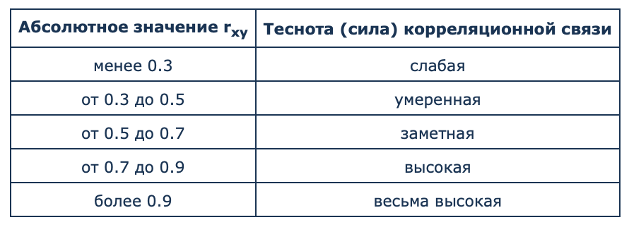

- **kendall : Kendall Tau correlation coefficient**

> Коэффициент ранговой корреляции tau-Кендалла является альтернативой методу определения корреляции Спирмана. Он предназначен для определения взаимосвязи между двумя ранговыми переменными. [Ссылка](https://statpsy.ru/kendall/correlation-kendall/)
- **spearman : Spearman rank correlation**

> мера линейной связи между случайными величинами. Корреляция Спирмена является ранговой, то есть для оценки силы связи используются не численные значения, а соответствующие им ранги. [Ссылка](http://www.machinelearning.ru/wiki/index.php?title=Коэффициент_корреляции_Спирмена)

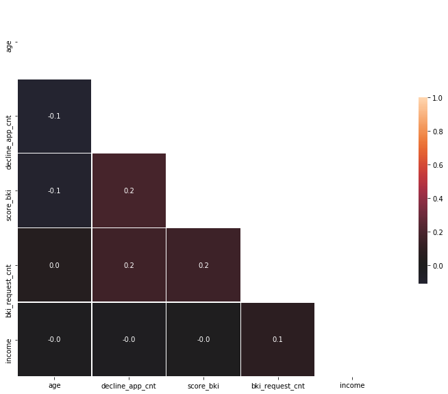

```python
num_cols = ['age','decline_app_cnt','score_bki','bki_request_cnt','income']
corr = df[num_cols].corr(method='pearson')

mask = np.zeros_like(corr, dtype=np.bool)
mask[np.triu_indices_from(mask)] = True

f, ax = plt.subplots(figsize=(15, 10))

sns.heatmap(corr, mask=mask, vmax=1, center=0, annot=True, fmt='.1f',
            square=True, linewidths=.5, cbar_kws={"shrink": .5});
```

## 4. Выбор метрики качества

*Внизу теоретическая часть, как выбирать метрику для своей задачи.*

[[1]](https://habr.com/ru/company/ods/blog/328372/) Хорошая статья на Хабре про метрики в общем и как их выбрать

[[2]](http://blog.datalytica.ru/2018/05/blog-post.html) Еще одна хорошая статья

[[3]](http://www.machinelearning.ru/wiki/index.php?title=Заглавная_страница) Хороший математический сайт о машинном обучении

Текст взят с сайта [[2]](http://blog.datalytica.ru/2018/05/blog-post.html)

**Классификация (classification)**: У вас есть ограниченное количество ответов - метки класса (class label). Ваша модель относит данные к какому-либо классу. Например болен-не болен.

- Confusion Matrix
- Accuracy Metric
- Recall/Sensitivity Metric
- Precision Metric
- F1 score

**Регрессия (regression)**: Предсказывает какое-либо число или числовой вектор (например, завтра будет такая-то температура)

- Mean Absolute Error (MAE)
- Mean Squared Error (MSE)
- Root Mean Squared Error (RMSE)

**Ранжирование (learning to rank)**: Модель будет предсказывать порядок элементов. Например, нам дали учебный класс и мы должны проранжировать учеников по росту, то есть, упорядочить их от самого высокого, до самого низкого.

- Простая метрика
- Kendall’s tau

Важно читать про каждую метрику и понимать ее недостатки.

Например, Accuracy Metric нельзя использовать при несбалансированных классах!

## 5. Построение модели и Оценивание качества модели

1. Смотрим внимательно на балансировку классов в модели

> [Про дисбаланс классов](https://habr.com/ru/post/349078/)

> [Обучающее видео](https://www.coursera.org/lecture/supervised-learning/niesbalansirovannyie-dannyie-M97UX)

> [Алгоритмы сэмлирования](http://neerc.ifmo.ru/wiki/index.php?title=Алгоритмы_сэмплирования)
1. Разбиваем данные
2. Выбираем модели, обучаем, смотрим метрики

```python
train_data = df.query('Train == 1').drop(['Train', 'client_id'], axis=1)
test_data = df.query('Train == 0').drop(['Train', 'client_id'], axis=1)

y = train_data.default.values # наш таргет
X = train_data.drop(['default'], axis=1)

# Воспользуемся специальной функцие train_test_split для разбивки тестовых данных
# выделим 20% данных на валидацию (параметр test_size)
X_train, X_test, y_train, y_test = train_test_split(X, y, test_size=0.2, random_state=RANDOM_SEED)

# проверяем
print(test_data.shape, train_data.shape, X.shape, X_train.shape, X_test.shape)
```

```
(36349, 18) (73799, 18) (73799, 17) (59039, 17) (14760, 17)
```

[Здесь красивый график](http://neerc.ifmo.ru/wiki/index.php?title=Модель_алгоритма_и_её_выбор) по выбору моделей

```python
# KNeighborsClassifier:
alg_ngbh = KNeighborsClassifier(n_neighbors=3)
alg_ngbh.fit(X_train, y_train)
y_pred_prob = alg_ngbh.predict_proba(X_test)[:,1]
y_pred = alg_ngbh.predict(X_test)
print("roc_auc_score (KNeighborsClassifier):", roc_auc_score(y_test, y_pred_prob))

# GaussianNB:
alg_nbs = GaussianNB()
alg_nbs.fit(X_train, y_train)
y_pred_prob = alg_nbs.predict_proba(X_test)[:,1]
y_pred = alg_nbs.predict(X_test)
print("roc_auc_score (naive bayes):", roc_auc_score(y_test, y_pred_prob))

# LogisticRegression:
alg_log = LogisticRegression(random_state=RANDOM_SEED, max_iter=200)
alg_log.fit(X_train, y_train)
y_pred_prob = alg_log.predict_proba(X_test)[:,1]
y_pred = alg_log.predict(X_test)
print("roc_auc_score (logistic regression):", roc_auc_score(y_test, y_pred_prob))

# RandomForestClassifier:
alg_frst = RandomForestClassifier(random_state=RANDOM_SEED, n_estimators=500, min_samples_split=8, min_samples_leaf=2)
alg_frst.fit(X_train, y_train)
y_pred_prob = alg_frst.predict_proba(X_test)[:,1]
y_pred = alg_frst.predict(X_test)
print("roc_auc_score (random forest):", roc_auc_score(y_test, y_pred_prob))

alg_gb = GradientBoostingClassifier(random_state=RANDOM_SEED)
alg_gb.fit(X_train, y_train)
y_pred_prob = alg_gb.predict_proba(X_test)[:,1]
y_pred = alg_gb.predict(X_test)
print("roc_auc_score (gradient boosting):", roc_auc_score(y_test, y_pred_prob))


#и существует еще большое множество моделей для этой задачи...
#поиск оптимальных параметров модели GridSearch
```

```
roc_auc_score (KNeighborsClassifier): 0.5352130603132451
roc_auc_score (naive bayes): 0.6720710092277613
roc_auc_score (logistic regression): 0.6653524114070111
roc_auc_score (random forest): 0.7264565204078398
roc_auc_score (gradient boosting): 0.7431903154953251
```

### Еще немного про метрики

В задачах классификации важной концепцией является матрица ошибок:

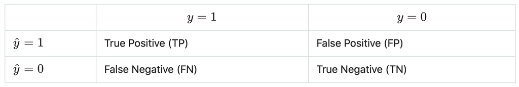

Здесь $\^ y$ — это ответ алгоритма на объекте, а $y$ — истинная метка класса на этом объекте.

Таким образом, ошибки классификации бывают двух видов: False Negative (FN) и False Positive (FP).

Дальше по [ссылке](https://habr.com/ru/company/ods/blog/328372/)

### Выбор параметров

[GridSearchCV](https://scikit-learn.org/stable/modules/generated/sklearn.model_selection.GridSearchCV.html)

### Выбор моделей

[Еще немного про алгоритмы МЛ](https://habr.com/ru/post/467825/)

$$**Теория**$$

# Линейная регрессия

[Текст частично взят отсюда](https://github.com/annshorn/ml-course-hse/blob/master/2016-fall/lecture-notes/lecture02-linregr.pdf)

## Линейные модели

Линейная модель - это суммирование признаков с некоторыми весами.

$$a(x) = w_0 + \sum_{j=1}^{d} w_j x_j$$

$w_j$ - параметры модели (или веса) $w_0$ - свободный коэффициент или сдвиг

## Метрики задач регрессии

#### 1. MSE

**Mean Squared Error** $$MSE(a, X) = \frac{1}{l} \sum_{i=1}^{l} (a(x_i) - y_i)^2$$

Плохо интерпретируется (единица измерения - квадрат оцениваемой величины. Если мы оцениваем рубли, то MSE выражается в квадратах рублей)

Поэтому используется RMSE, который имеет те же единицы измерения, что и оцениваемая величина.

**Root Mean Squared Error**

$$RMSE(a, X) = \sqrt{\frac{1}{l} \sum_{i=1}^{l} (a(x_i) - y_i)^2}$$

$$Сравнение$$

RMSE более чувствителен к большим ошибкам. [Картинка отсюда](https://medium.com/human-in-a-machine-world/mae-and-rmse-which-metric-is-better-e60ac3bde13d)

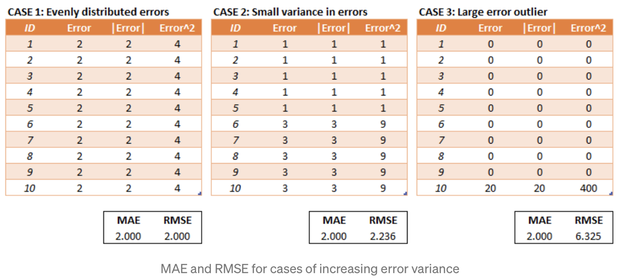

> Среднеквадратичная ошибка подходит для сравнения двух моделей или для контроля качества во время обучения, но не подходит для вывода, насколько данная модель хорошо решает задачу.

Например, MSE = 10 является очень плохим показателем, если целевая переменная принимает значения от 0 до 1, и очень хорошим, если целевая переменная лежит в интервале (10000, 100000).

В таких ситуациях вместо среднеквадратичной ошибки полезно использовать коэффициент детерминации (или коэффициент $R^2$)

#### 2. $R^2$

$$ R^2(a, X) = 1 - \frac{ \sum_{i=1}^{l} (a(x_i) - y_i)^2 }{ \sum_{i=1}^{l} (y_i - y)^2} $$$$ y = \frac{1}{l} \sum_{i=1}^{l} y_i $$

- среднее значение целевой переменной

Коэффициент детерминации измеряет долю дисперсии, объяснённую моделью, в общей дисперсии целевой переменной. Фактически, данная мера качества — это нормированная среднеквадратичная ошибка.

Если она близка к единице, то модель хорошо объясняет данные, если же она близка к нулю, то прогнозы сопоставимы по качеству с константным предсказанием.

#### 3. MAE

Среднее абсолютное отклонение (mean absolute error, MAE):

$$ MAE(a, X) = \frac{1}{l} \sum_{i=1}^{l} |a(y_i) - y_i| $$

Квадрат отклонения делает особый акцент на объектах с сильной ошибкой, и метод обучения будет в первую очередь стараться уменьшить отклонения на таких объектах.

Если же эти объекты являются выбросами (то есть значение целевой переменной на них либо ошибочно, либо относится к другому распределению и должно быть проигнорировано), то такая расстановка акцентов приведёт к плохому качеству модели.

Модуль отклонения в этом смысле гораздо более терпим к сильным ошибкам.

Допустим, все $l$ объектов выборки имеют одинаковые признаковые описания, но разные значения целевой переменной $y_1,...,y_l$. В этом случае модель должна на всех этих объектах выдать один и тот же ответ.

#### 4. MSLE

Среднеквадратичная логарифмическая ошибка (mean squared logarithmic error, MSLE):

$$ L(y, a) = (log(a + 1) − log(y + 1))^2 $$

Данная метрика подходит для задач с неотрицательной целевой переменной. За счёт логарифмирования ответов и прогнозов мы скорее штрафуем за отклонения в порядке величин, чем за отклонения в их значениях.

Также следует помнить, что логарифм не является симметричной функцией, и поэтому данная функция потерь штрафует заниженные прогнозы сильнее, чем завышенные.

#### 4. MAPE и SMAPE

В задачах прогнозирования обычно измеряется относительная ошибка:

$$ L(y, a) = |\frac{y-a}{y}| $$

Соответствующий функционал называется средней абсолютной процентной ошибкой (mean absolute percentage error, MAPE). Данный функционал часто используется в задачах прогнозирования.

Также используется его симметричная модификация (symmetric mean absolute percentage error, SMAPE):

$$ L(y, a) = \frac{|y-a|}{(|y| + |a|)/2} $$

## Обучение линейной регрессии

Придется почитать про методы оптимизации.

Оптимизация — в математике, информатике и исследовании операций задача нахождения экстремума (минимума или максимума) целевой функции в некоторой области конечномерного векторного пространства, ограниченной набором линейных и/или нелинейных равенств и/или неравенств. Википедия)

[Ознакомиться и порешать задачи. Источник 1](http://tc.nsu.ru/uploads/met-opt-pr-zad.pdf)

[Лекции](http://www.machinelearning.ru/wiki/index.php?title=Методы_оптимизации_%28курс_лекций%29)

Дальше текст [отсюда](https://github.com/annshorn/ml-course-hse/blob/master/2016-fall/lecture-notes/lecture02-linregr.pdf)

Чаще всего линейная регрессия обучается с использованием среднеквадратичной ошибки.

В этом случае получаем задачу оптимизации (считаем, что среди при- знаков есть константный, и поэтому свободный коэффициент не нужен):

$$MSE(a, X) = \frac{1}{l} \sum_{i=1}^{l} (a(x_i) - y_i)^2$$$$MSE(a, X) = \frac{1}{l} \sum_{i=1}^{l} (<w, x_i> - y_i)^2 \rightarrow min_w$$

В матричном виде, где $X$ - матрица признаков, $w$ - вектор параметров, $y$ - вектор ответов:

$$\frac{1}{l} \| Xw - y \|^2 \rightarrow min_w$$

*Почему такой переход? [Ссылка](https://ru.wikipedia.org/wiki/Норма*(математика)), читаем про L-2 норму, а именно, что такой вид записи эквивалентен предыдущему шагу._

Решаем задачу оптимизации, а именно - ищем экстремум, то есть берем производную и приравниваем все к нулю.

_[Матрично-векторное дифференцирование](http://www.machinelearning.ru/wiki/images/5/50/MOMO17_Seminar2.pdf)_

$$\frac{1}{l} d(\| Xw - y \|^2) = d(<Xw - y, Xw - y>) = \frac{2}{l} <Xw - y, d(Xw - y)> = \frac{2}{l} <Xw - y, Xdw> = $$$$= \frac{2}{l} <Xw - y, Xdw> = \frac{2}{l} <X^{T}(Xw - y), dw>$$$$ \nabla f(w) = X^{T}(Xw - y) = 0$$$$ X^{T}Xw - X^{T}y = 0$$$$ X^{T}Xw = X^{T}y $$

Явная формула для решения задачи поиска оптимальных весов:

$$ w = (X^{T}X)^{-1}X^{T}y$$

Поиск явной формулы не всегда применима:

1. Не всегда удается найти явное решение для функционала!
1. Обращение матрицы — сложная операция с кубической сложностью от количества признаков. Если в выборке тысячи признаков, то вычисления могут стать слишком трудоёмкими. Решить эту проблему можно путём использования численных методов оптимизации.
1. Матрица $X^{T}X$ может быть вырожденной или плохо обусловленной. В этом случае обращение либо невозможно, либо может привести к неустойчивым результатам. Проблема решается с помощью регуляризации, речь о которой пойдёт ниже.

### Градиентный спуск

Оптимизационную задачу можно решать итерационно.

[Градиент](http://mathprofi.ru/proizvodnaja_po_napravleniju_i_gradient.html) - очень хороший сайт, где все подробно объясняется

Градиент - это направление наискорейшего роста функции, а антиградиент - направление наискорейшего убывания.

Основное свойство антиградиента — он указывает в сторону наискорейшего убывания функции в данной точке.

Соответственно, будет логично стартовать из некоторой точки, сдвинуться в сторону антиградиента, пересчитать антиградиент и снова сдвинуться в его сторону и т.д.

$w^{(0)}$ - начальный набор параметров (нулевой или сгенерированный рандомно)

Тогда градиентный спуск состоит в повторении следующих шагов до *сходимости*:

$$ w^{(k)} = w^{(k-1)} - \eta_k \nabla Q(w^{(k-1)}) $$

$Q(w)$ - значение функционала ошибки для набора параметров $w$

$\eta_k$ - длина шага, необходимая для контроля скорости движения. Ее можно сделать константой, но тогда, если число будет большим, можно постоянно перепрыгивать через точку минимума. Если сделать это число большим, то итерационный процесс будет очень долгим. Иногда длинну шага уменьшают по формуле $\eta_k = \frac{1}{k}$

Останавливать итерационный процесс можно, например, при близости градиента к нулю или при слишком малом изменении вектора весов на последней итерации.

Если функционал $Q(w)$ выпуклый, гладкий и имеет минимум $w^*$, то имеет место следующая оценка сходимости:

$Q(w^{k}) - Q(w^{*}) = O(1/k)$

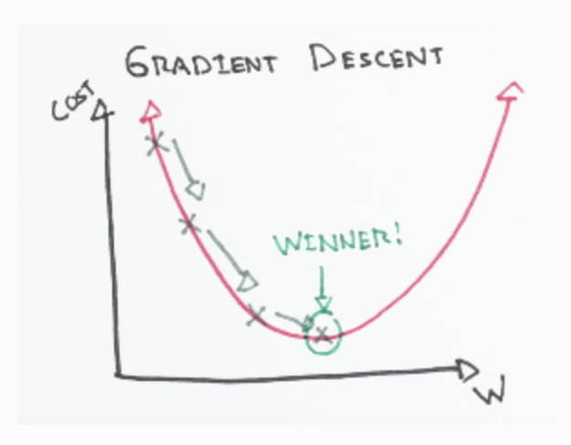

### Оценивание градиента

$Q(w) = \sum_{i=1}^{l} q_i(w)$

Каждая отдельные функции $q_i(w)$ соответствуют ошибкам на отдельных объектах.

Проблема метода градиентного спуска состоит в том, что на каждом шаге необходимо вычислять градиент всей суммы (будем его называть полным градиентом):

$\nabla Q(w) = \sum_{i=1}^{l} \nabla q_i(w)$

[Маленький пример реализации градиентного спуска](https://ml-cheatsheet.readthedocs.io/en/latest/gradient_descent.html)

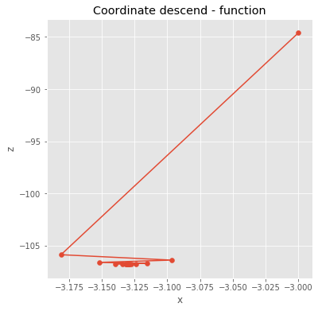

```python
'''
Как лучше понять методы оптимизации?
Конечно же запрогать алгоритм!


Вот например моя реализация координатного спуска
https://en.wikipedia.org/wiki/Coordinate_descent
'''
import math

def compute(point):
    #domain should be < 25
    domain = (point[0]+5)**2 + (point[1]+5)**2
    if domain >= 25:
        #print('Point does not belong to this domain:', point)
        return np.inf
    else:
        answer = math.sin(point[1])*math.exp((1-math.cos(point[0]))**2) + math.cos(point[0])*math.exp((1 - math.sin(point[1]))**2) + (point[0] - point[1])**2
        return answer


def diff_x(x, y):
    func_diff_x = 2*(x-y) - np.sin(x)*np.exp((1-np.sin(y))**2) + 2*np.sin(x)*(np.exp((1-np.cos(x))**2))*(1-np.cos(x))*np.sin(y)
    return func_diff_x

def diff_y(x, y):
    func_diff_y = -2*(x-y) + np.cos(y)*np.exp((1-np.cos(x))**2) - 2*np.cos(x)*np.cos(y)*(1-np.sin(y))*np.exp((1-np.sin(y))**2)
    return func_diff_y

def Coordinate_descend(point, alfa, iterat):

    k = 1
    x_array = [point[0]]
    y_array = [point[1]]
    function = compute(point)
    funct = [function]

    num=0

    while k < iterat:

        x_array.append(x_array[k-1] - alfa*diff_x(x_array[k-1], y_array[k-1]))
        y_array.append(y_array[k-1] - alfa*diff_y(x_array[k-1], y_array[k-1]))

        #alfa = alfa/(k)
        #print(alfa)
        points = [x_array[k], y_array[k]]
        function = compute(points)
        funct.append(function)

        k+=1

        if (function + 106.7645) < 10e-3:
            num +=1

    return function, funct, x_array, y_array, num


point = [-3, -2]
alfa = 0.006
iterat = 100
function, funct, x_array, y_array, num  = Coordinate_descend(point, alfa, iterat)

plt.figure(figsize=(6,6))
plt.plot(x_array, funct)
plt.scatter(x_array, funct)
plt.title('Coordinate descend - function')
plt.xlabel('x')
plt.ylabel('z')
plt.show()
```

### Переобучение

[Видео от курса физтеха: методы борьбы с переобучением](https://www.coursera.org/lecture/supervised-learning/probliema-pierieobuchieniia-GhyDw)

[Переобучением математическим языком :)](http://www.machinelearning.ru/wiki/index.php?title=Переобучение)

### Регуляризация

Регуляризация в статистике, машинном обучении, теории обратных задач — метод добавления некоторых дополнительных ограничений к условию с целью решить некорректно поставленную задачу или предотвратить переобучение. Эта информация часто имеет вид штрафа за сложность модели.Википедия)

[Текст](https://learnmachinelearning.wikia.org/ru/wiki/Регуляризация)

Часто регуляризация представляет собой просто некоторую добавку $R(w)$ (где w — параметры модели) к функции потерь $Q(w)$ так что задача приобретает вид:

$$min_w \sum_{i=1}^{l} Q(w) + \lambda R(w)$$

### Гиперпараметры

В машинном обучении принято разделять подлежащие настройке величины на параметры и гиперпараметры.

Параметрами называют величины, которые настраиваются по обучающей выборки — например, веса в линейной регрессии.

К гиперпараметрам относят величины, которые контролируют сам процесс обучения и не могут быть подобраны по обучающей выборке.

Хорошим примером гиперпараметра является коэффициент регуляризации $\lambda$. Введение регуляризации мешает модели подгоняться под обучающие данные, и с точки зрения среднеквадратичной ошибки выгодно всегда брать α = 0. Разумеется, такой выбор не будет оптимальным с точки зрения качества на новых данных, и поэтому коэффициент регуляризации (как и другие гиперпараметры) следует настраивать по отложенной выборке или с помощью кросс-валидации.

При подборе гиперпараметров по кросс-валидации возникает проблема: мы используем отложенные данные, чтобы выбрать лучший набор гиперпараметров. По сути, отложенная выборка тоже становится обучающей, и показатели качества на ней перестают характеризовать обобщающую способность модели. В таких случаях выборку, на которой настраиваются гиперпараметры, называют валидационной, и при этом выделяют третий, тестовый набор данных, на которых оценивается качество итоговой модели.

### Масштабирование

При обучении линейных моделей полезно масштабировать признаки, то есть приводить их к единой шкале.

$$ f_1 (x) = x^2_1 + x^2_2 $$

Начальное приближение $x^{(0)} = (1,1)$ и запустим из него градиентный спуск.

Окажется, что за один шаг мы сможем сразу попасть в точку минимума.

Теперь «растянем» функцию вдоль одной из осей:

$$ f_1 (x) = 100 x^2_1 + x^2_2 $$

Аналогичная проблема возникает с функционалом ошибки в линейной регрес- сии, если один из признаков существенно отличается по масштабу от остальных.

# Линейная классификация

[Текст отсюда](https://github.com/annshorn/ml-course-hse/blob/master/2016-fall/lecture-notes/lecture04-linclass.pdf)

$X = \{(x_i, y_i)\}^{l}_{i=1}$ - пространство объектов

$Y = \{-1, +1\}$ - множество допустимых ответов

Класс "-1" будем называть отрицательным, класс "+1" - положительным

Линейная модель классификации определяется следующим образом:

$$ a(x) = sign(<w, x> + w_0) = sign(\sum_{j=1}^{d} w_j x_j + w_0) $$

$w$ - вектор весов

$w_0$ - сдвиг

Если не сказано иначе, мы будем считать, что среди признаков есть константа, $x_{d+1} = 1$.

$$ a(x) = sign<w, x>$$

У нас всего два возможных ответа алгоритма и, очевидно, мы хотим видеть как можно больше правильных ответов. Соответствующий функционал называется долей правильных ответов (accuracy):

$$ Q(a, X) = \frac{1}{l} \sum_{i=1}^{l} [ a(x_i) = y_i]$$

Решаем задачу минимизации:

$$ Q(a, X) = \frac{1}{l} \sum_{i=1}^{l} [ a(x_i) \neq y_i] = \frac{1}{l} \sum_{i=1}^{l} [ sign<w, x_i> \neq y_i] \rightarrow min_w $$

Продолжим на следующем звонке.

[Ссылка](https://habr.com/ru/company/ods/blog/323890/#1-lineynaya-regressiya)

# Проект 5: Выбор авто

Вы работаете в компании, которая занимается продажей автомобилей с пробегом в Москве.

Основная задача компании и её менеджеров — максимально быстро находить выгодные предложения (проще говоря, купить ниже рынка, а продать дороже рынка).

Руководство компании просит вашу команду создать модель, которая будет предсказывать стоимость автомобиля по его характеристикам.

### Из приятного:

1. Попробуем новую метрику!
2. Данных нет :) Только тестовая выборка, придется формировать самому!

### Чему можно новому научиться и что полезно?

- **requests, BeautifulSoup, selenium, scrapy** — библиотеки для парсинга данных;
- **re** — библиотека для работы с регулярными выражениями.

**Я хочу спарсить сайт, как мне двигаться?**

1. Открыть сайт :)
2. Прогуглить "парсинг сайта python"
3. Открыть ссылку, [например](https://python-scripts.com/beautifulsoup-html-parsing)
4. Воспользоваться разными библиотеками и посмотреть, какая библиотека *чище* всего открывает ссылку.
5. Чистить данные, формировать данные :)

По личному опыту: с каждым сайтом работает своя библиотека.

Пользовалась: requests, BeautifulSoup, selenium и html

### Максимально неприятный пример - парсинг текста

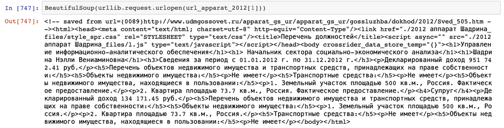

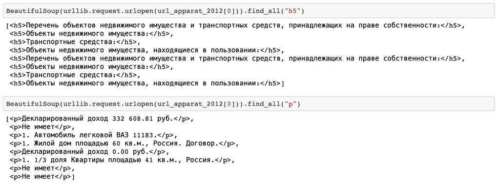

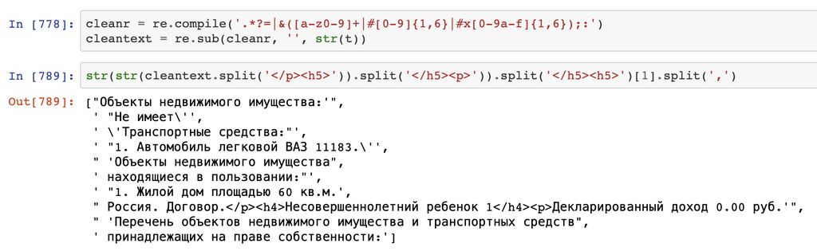

### Максимально приятный пример - парсинг таблиц

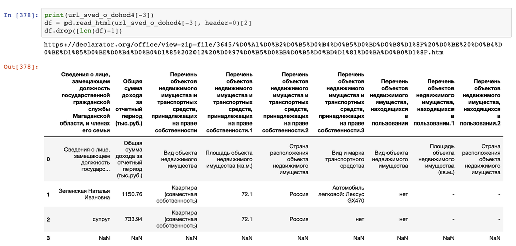

### Максимально средний пример - парсинг удобных сайтов (Пример с аптеками)

```python
from __future__ import division, unicode_literals
import codecs
from bs4 import BeautifulSoup

import pandas as pd
import numpy as np

import urllib.parse
from urllib.parse import quote_plus, quote

from urllib.request import urlopen
from tqdm import tqdm_notebook as tqdm

import matplotlib.pyplot as plt
plt.style.use('ggplot')
%matplotlib inline

#импортирование необходимых библиотек для работы

#вспомогательная функция проверки нахождения информации на странице
#number_of_pages максимальное количество страниц для проверки (можно изменить)
def check_url(url, number_of_pages = 10):
    array = []
    for i in tqdm(range(number_of_pages)):
        url_name = 'https://lekmos.ru/tn.phtml?id=13286' + '&page=' + str(i)
        open_url = urllib.request.urlopen(url_name)
        f = BeautifulSoup(open_url).find_all("tr")#[9]
        print(f)
        if str(f)[8:-11] == 'Предложения не обнаружены':
            continue
        else:
            array.append(url_name)
    return array

#вспомогательная функция
#считывает содержание html
#выдает dataframe
def read_html(url, name):
    read = BeautifulSoup(urllib.request.urlopen(url))
    useful_data_from_html = []
    i = 0 #в каждой нечетной части содержится повторная информация
    for each_tr in read.find_all("tr")[9:]: #с 9 начинаются перечисления лекарств-аптек
        if i == 0 or i % 2 == 0:
            useful_data_from_html.append(each_tr.find_all("td")[2:])
        i+=1

    #заполнение массивов полезной информацией
    array_name = []
    array_firm = []
    array_date = []
    array_quantity = []
    array_price = []
    for data in useful_data_from_html:
        if data == []:
            continue
        else:
            array_name.append( data[0].find_all('img', alt=True)[0]['alt']) #аптека
            array_firm.append(str(data[1])[4:-5]) #фирма
            array_date.append(str(data[2])[4:-5]) #дата
            array_quantity.append(str(data[3])[4:-5]) #количество
            array_price.append(str(data[4])[4:-5]) #цена

    main_name = np.full(len(array_name), name)
    df = pd.DataFrame(main_name, columns = ['drug name'])
    df['name'] = array_name
    df['firm'] = array_firm
    df['date'] = array_date
    df['quantity'] = array_quantity
    df['price'] = array_price

    return df


#запрос ссылки на данные с сайта lekmos.ru/
#функция принимает название из списка противовирусных
#и возвращает таблицу

#при разных дозировках используется
#всегда первый вариант из представленных

#данные, которые можно вытащить с сайта lekmos.ru/:

#Название аптеки
#Производство
#Дата
#Наличие, шт.
#Цена, руб.

def drug_url(name):
    main_url = 'https://lekmos.ru/' #главная ссылка на сайт

    main_df = pd.DataFrame(columns=['drug name', 'name', 'firm', 'date', 'quantity', 'price'])

    if name == 'Кагоцел':
        kagozel_url = check_url(main_url + 'tn.phtml?id=13286')
        for each_url in kagozel_url:
            #print(read_html(each_url, 'Кагоцел'))
            main_df = main_df.append( read_html(each_url, 'Кагоцел'), ignore_index = True)

    return main_df

kagozel = drug_url('Кагоцел')
display(kagozel.head())
```

```
[]
[]
[]
[]
[]
[]
[]
[]
[]
[]
```

|  | drug name | name | firm | date | quantity | price |
| --- | --- | --- | --- | --- | --- | --- |

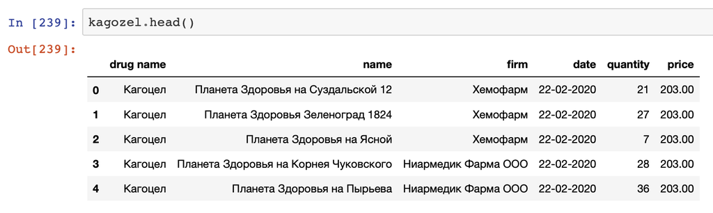